# Lista 01 - Exercício 19

Willian Meira Schlichta

2 de outubro de 2018

**Exercício 19** - No arquivo *reg3.dat* são descritas as seguintes variáveis referentes a 50 estados norte-americanos:

1. Estado (nome do estado);
2. Pop (população estimada em julho de 1975);
3. Percap (renda percapita em 1974 em USD);
4. Analf (proporção de analfabetos em 1970);
5. Expvida (expectativa de vida em anos 1969-70)
6. Crime (taxa de criminalidade por 100000 habitantes 1976);
7. Estud (porcentagem de estudantes que concluem o segundo grau 1970);
8. Nndias (número de dias do ano com temperatura abaixo de zero grau Celsus no estado);
9. Area (área do estado em milhas quadradas).

O objetivo do estudo é tentar explicar e variável **expvida** usando um modelo de regressão normal linear dadas as variáveis explicativas *percap*, *analf*, *crime*, *estud*, *ndias* e *dens*, em que *dens = pop / area*.

Inicialmente faça uma análise descritiva dos dados, por exemplo com boxplots de cada uma das variáveis que serão consideradas no estudo e com diagramas de dispersão com as respectivas tendências entre as variáveis explicativas e a variável resposta. Comente essa parte descritiva.

Posteriormente, ajuste o modelo de regressão normal linear com todas as variáveis explicativas e através do método AIC faça uma seleção de variáveis.

Uma vez selecionado o modelo faça uma análise de diagnóstico e apresente as interpretações dos coeficientes estimados do modelo final.

**Resolução**

Carregando os dados, nomeando as varíaveis e adicionando a variável *dens* na base:

```r
base_Ex19 <- read.table('https://www.ime.usp.br/~giapaula/reg3.dat',header=F)
names(base_Ex19)<-c('estad','popul','renda','analf','expvi','crime','estud','ndias','area')
base_Ex19$densi <- base_Ex19$pop/base_Ex19$area
dim(base_Ex19)
```

```
## [1] 50 10
```

```r
str(base_Ex19)
```

```
## 'data.frame':    50 obs. of  10 variables:
##  $ estad: Factor w/ 50 levels "Alabama","Alaska",..: 1 2 3 4 5 6 7 8 9 10 ...
##  $ popul: int  3615 365 2212 2110 21198 2541 3100 579 8277 4931 ...
##  $ renda: int  3624 6315 4530 3378 5114 4884 5348 4809 4815 4091 ...
##  $ analf: num  2.1 1.5 1.8 1.9 1.1 0.7 1.1 0.9 1.3 2 ...
##  $ expvi: num  69 69.3 70.5 70.7 71.7 ...
##  $ crime: num  15.1 11.3 7.8 10.1 10.3 6.8 3.1 6.2 10.7 13.9 ...
##  $ estud: num  41.3 66.7 58.1 39.9 62.6 63.9 56 54.6 52.6 40.6 ...
##  $ ndias: int  20 152 15 65 20 166 139 103 11 60 ...
##  $ area : int  50708 566432 113417 51945 156361 103766 4862 1982 54090 58073 ...
##  $ densi: num  0.071291 0.000644 0.019503 0.04062 0.135571 ...
```

```r
summary(base_Ex19)
```

```
##         estad        popul           renda          analf
##  Alabama   : 1   Min.   :  365   Min.   :3098   Min.   :0.500
##  Alaska    : 1   1st Qu.: 1080   1st Qu.:3993   1st Qu.:0.625
##  Arizona   : 1   Median : 2838   Median :4519   Median :0.950
##  Arkansas  : 1   Mean   : 4246   Mean   :4436   Mean   :1.170
##  California: 1   3rd Qu.: 4968   3rd Qu.:4814   3rd Qu.:1.575
##  Colorado  : 1   Max.   :21198   Max.   :6315   Max.   :2.800
##  (Other)   :44
##      expvi           crime            estud           ndias
##  Min.   :67.96   Min.   : 1.400   Min.   :37.80   Min.   :  0.00
##  1st Qu.:70.12   1st Qu.: 4.350   1st Qu.:48.05   1st Qu.: 66.25
##  Median :70.67   Median : 6.850   Median :53.25   Median :114.50
##  Mean   :70.88   Mean   : 7.378   Mean   :53.11   Mean   :104.46
##  3rd Qu.:71.89   3rd Qu.:10.675   3rd Qu.:59.15   3rd Qu.:139.75
##  Max.   :73.60   Max.   :15.100   Max.   :67.30   Max.   :188.00
##
##       area            densi
##  Min.   :  1049   Min.   :0.0006444
##  1st Qu.: 32214   1st Qu.:0.0277301
##  Median : 54277   Median :0.0690245
##  Mean   : 72862   Mean   :0.1879502
##  3rd Qu.: 82019   3rd Qu.:0.1442828
##  Max.   :566432   Max.   :2.6844614
##
```

```r
vars <- c("expvi","renda", "analf", "crime", "estud", "ndias", "densi")
m1 <- base_Ex19[, vars]
m1
```

```
##    expvi renda analf crime estud ndias        densi
## 1  69.05  3624   2.1  15.1  41.3    20 0.0712905261
## 2  69.31  6315   1.5  11.3  66.7   152 0.0006443845
## 3  70.55  4530   1.8   7.8  58.1    15 0.0195032491
## 4  70.66  3378   1.9  10.1  39.9    65 0.0406198864
## 5  71.71  5114   1.1  10.3  62.6    20 0.1355708904
## 6  72.06  4884   0.7   6.8  63.9   166 0.0244877898
## 7  72.48  5348   1.1   3.1  56.0   139 0.6375976964
## 8  70.06  4809   0.9   6.2  54.6   103 0.2921291625
## 9  70.66  4815   1.3  10.7  52.6    11 0.1530227399
## 10 68.54  4091   2.0  13.9  40.6    60 0.0849103714
## 11 73.60  4963   1.9   6.2  61.9     0 0.1350972763
## 12 71.87  4119   0.6   5.3  59.5   126 0.0098334482
## 13 70.14  5107   0.9  10.3  52.6   127 0.2008502547
## 14 70.88  4458   0.7   7.1  52.9   122 0.1471867468
```

[output cut: 36 more lines]

```r
dim(m1)
```

```
## [1] 50  7
```

```r
str(m1)
```

```
## 'data.frame':    50 obs. of  7 variables:
##  $ expvi: num  69 69.3 70.5 70.7 71.7 ...
##  $ renda: int  3624 6315 4530 3378 5114 4884 5348 4809 4815 4091 ...
##  $ analf: num  2.1 1.5 1.8 1.9 1.1 0.7 1.1 0.9 1.3 2 ...
##  $ crime: num  15.1 11.3 7.8 10.1 10.3 6.8 3.1 6.2 10.7 13.9 ...
##  $ estud: num  41.3 66.7 58.1 39.9 62.6 63.9 56 54.6 52.6 40.6 ...
##  $ ndias: int  20 152 15 65 20 166 139 103 11 60 ...
##  $ densi: num  0.071291 0.000644 0.019503 0.04062 0.135571 ...
```

```r
summary(m1)
```

```
##      expvi           renda          analf           crime
##  Min.   :67.96   Min.   :3098   Min.   :0.500   Min.   : 1.400
##  1st Qu.:70.12   1st Qu.:3993   1st Qu.:0.625   1st Qu.: 4.350
##  Median :70.67   Median :4519   Median :0.950   Median : 6.850
##  Mean   :70.88   Mean   :4436   Mean   :1.170   Mean   : 7.378
##  3rd Qu.:71.89   3rd Qu.:4814   3rd Qu.:1.575   3rd Qu.:10.675
##  Max.   :73.60   Max.   :6315   Max.   :2.800   Max.   :15.100
##      estud           ndias            densi
##  Min.   :37.80   Min.   :  0.00   Min.   :0.0006444
##  1st Qu.:48.05   1st Qu.: 66.25   1st Qu.:0.0277301
##  Median :53.25   Median :114.50   Median :0.0690245
##  Mean   :53.11   Mean   :104.46   Mean   :0.1879502
##  3rd Qu.:59.15   3rd Qu.:139.75   3rd Qu.:0.1442828
##  Max.   :67.30   Max.   :188.00   Max.   :2.6844614
```

```r
m2 <- apply(base_Ex19[, vars], 2, summary)
kable(m2)
```

|  | expvi | renda | analf | crime | estud | ndias | densi |
| --- | --- | --- | --- | --- | --- | --- | --- |
| Min. | 67.9600 | 3098.00 | 0.500 | 1.400 | 37.800 | 0.00 | 0.0006444 |
| 1st Qu. | 70.1175 | 3992.75 | 0.625 | 4.350 | 48.050 | 66.25 | 0.0277301 |
| Median | 70.6750 | 4519.00 | 0.950 | 6.850 | 53.250 | 114.50 | 0.0690245 |
| Mean | 70.8786 | 4435.80 | 1.170 | 7.378 | 53.108 | 104.46 | 0.1879502 |
| 3rd Qu. | 71.8925 | 4813.50 | 1.575 | 10.675 | 59.150 | 139.75 | 0.1442828 |
| Max. | 73.6000 | 6315.00 | 2.800 | 15.100 | 67.300 | 188.00 | 2.6844614 |

```r
kable(head(m1),digits = 4,caption = "tittab1")
```

| expvi | renda | analf | crime | estud | ndias | densi |
| --- | --- | --- | --- | --- | --- | --- |
| 69.05 | 3624 | 2.1 | 15.1 | 41.3 | 20 | 0.0713 |
| 69.31 | 6315 | 1.5 | 11.3 | 66.7 | 152 | 0.0006 |
| 70.55 | 4530 | 1.8 | 7.8 | 58.1 | 15 | 0.0195 |
| 70.66 | 3378 | 1.9 | 10.1 | 39.9 | 65 | 0.0406 |
| 71.71 | 5114 | 1.1 | 10.3 | 62.6 | 20 | 0.1356 |
| 72.06 | 4884 | 0.7 | 6.8 | 63.9 | 166 | 0.0245 |

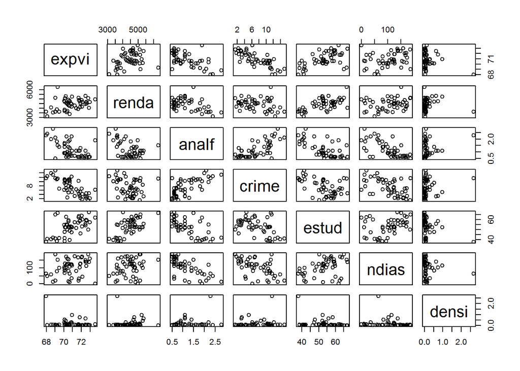

```r
pairs(m1)
```

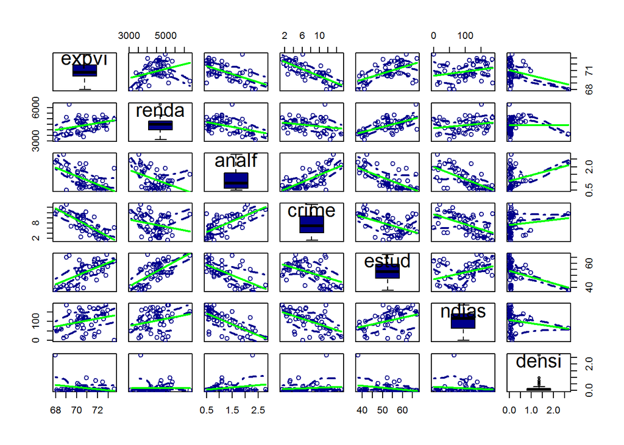

```r
scatterplotMatrix(m1,
                  diagonal=list(method="boxplot"),
                  regLine = list(method=lm, lty=1, lwd=2, col="green"),
                  col=c("darkblue", "blue", "green"))
```

[figure not shown]

```r
ggplot(base_Ex19, aes(x=estad, y=expvi)) +
  geom_boxplot() +
  stat_summary(fun.y=median, geom="line", lwd=1, aes(group=1))
```

## **************************************************

# códigos de exemplo do professor

names(ajuste1) ### Retorna a relação dos resultados produzidos pela função lm. ### Para mais informações, consultar a documentação - help(‘lm’)

ajuste2 <- lm(Viscosidade ~ scale(Temperatura,scale=F) + scale(Alimentação,scale=F), data=Ex19) ### Ajuste alternativo, ‘centrando’ as variáveis explicativas, ### ou seja, diminuindo de cada observação das variáveis explicativas a respectiva média.

summary(ajuste2) ### O que mudou?

### Diagnóstico do modelo

ajuste1$residuals # Vetor de resíduos ordinarios residuos <- rstandard(ajuste1);residuos # Vetor de resíduos padronizados rstudent(ajuste1) # Vetor de resíduos studentizados

preditos <- ajuste1$fitted.values # Vetor de valores ajustados pelo modelo.

summary(ajuste1) summary(update(ajuste1, subset = -4)) summary(update(ajuste1, subset = -7)) summary(update(ajuste1, subset = -c(4,7)))

### Intervalos de confiança para os parâmetros do modelo.

confint(ajuste1)

### Algumas predições

predict(ajuste1) ### Viscosidade estimada para cada observação na base.

predict(ajuste1, interval = ‘confidence’) ### Viscosidade estimada e intervalo de confiança (95%) para a viscosidade ### média.

predict(ajuste1, interval = ‘prediction’) ### Viscosidade estimada e intervalo de predição (95%) para a viscosidade ### de uma nova observação.

### Agora, vamos repetir os códigos considerando um par de valores diferente

### dos que aparecem na base.

predict(ajuste1, newdata = data.frame(Temperatura = 95, Alimentação = 11)) predict(ajuste1, newdata = data.frame(Temperatura = 95, Alimentação = 11), interval = ‘confidence’) predict(ajuste1, newdata = data.frame(Temperatura = 95, Alimentação = 11), interval = ‘prediction’)

### Gráficos para a viscosidade estimada com bandas de confiança.

plot(effect(“Temperatura”, ajuste1)) ### Viscosidade estimada versus temperatura (alimentação fixada na média)

plot(effect(“Alimentação”, ajuste1)) ### Viscosidade estimada versus alimentação (temperatura fixada na média)

plot(effect(“Alimentação”, given.values = c(Temperatura = 85), ajuste1)) ### Viscosidade estimada versus alimentação (temperatura fixada em 85)

plot(effect(“Temperatura”, given.values = c(Alimentação = 12), ajuste1)) ### Viscosidade estimada versus temperatura (alimentação fixada em 12)

### Exemplo 2 - vendas segundo o tipo de embalagem.

Embalagem <- rep(c(‘E1’,‘E2’,‘E3’,‘E4’), each=3) Vendas <- c(11,18,13,14,10,12,19,17,21,24,30,27)

# Descrição dos dados

stripchart(Vendas ~ Embalagem, vertical=T, pch=20) # Gráfico de vendas vs embalagem. ### Há fortes indícios de diferença nas vendas conforme o tipo de embalagem.

tapply(Vendas, Embalagem, mean) # Vendas médias por tipo de embalagem. tapply(Vendas, Embalagem, sd) # Desvios padrões das vendas por tipo de embalagem.

### Ajuste do modelo de análise de variância com um fator

modelo1 <- lm(Vendas ~ Embalagem) anova(modelo1) ### A análise de variância confirma as evidências anteriores ### de que as vendas, em média, variam conforme o tipo de embalagem. summary(modelo1) ### Repare que nessa parametrização o intercepro corresponde ### à média para a embalagem 1 e os demais parâmetros às diferenças das médias ### para as embalagens 2, 3 e 4 em relação à média da embalagem 1.

### vendas médias proporcionadas pelas embalagens 1 e 2.

### Nota - se desejado, poderia prosseguir com a execução de algum teste

### de comparações múltiplas.

names(modelo1) model.matrix(modelo1) # Matriz do modelo (X).

### Ajuste do modelo sem intercepto (parametrização alternativa)

modelo2 <- lm(Vendas ~ Embalagem-1) summary(modelo2) ### Agora, os quatro parâmetros correspondem às vendas médias das quatro embalagens.

### Diagnóstico do modelo

residuos <- rstandard(modelo1) # Vetor de resíduos preditos <- modelo1$fitted.values # Vetor de valores ajustados

par(mfrow=c(1,2)) hist(residuos) qqnorm(residuos) qqline(residuos) ### Sem problemas quanto ao pressuposto de normalidade.

### Intervalos de confiança sob as duas parametrizações.

confint(modelo1) confint(modelo2)

### Vamos testar algumas hipóteses referentes a combinações lineares dos parâmetros.

linearHypothesis(modelo2, “1*EmbalagemE4 - 1*EmbalagemE3 = 0”) ### Testando a igualdade de médias das embalagens 3 e 4.

linearHypothesis(modelo2, “1*EmbalagemE3 - 0.5*EmbalagemE4 - 0.5*EmbalagemE2 = 0“) ### Testando a igualdade da embalagem 3 e da média das embalagens 4 e 2.

## **************************************************